# Stan and Torsten

## Issues in using Torsten

We had difficulties when calling Torsten built-in functions via rstan package due to the recent updates in Torsten functions. These features are updated to Stan version 2.19.1.

### Function names

According to a recent github post, the following functions are renamed:

- `PKModelOneCpt` → `pmx_solve_onecpt`
- `PKModelTwoCpt` → `pmx_solve_twocpt`
- `linOdeModel` → `pmx_solve_linode`
- `generalOdeModel_adams` → `pmx_solve_adams`
- `generalOdeModel_bdf` → `pmx_solve_bdf`
- `generalOdeModel_rk45` → `pmx_solve_rk45`
- `mixOde1CptModel_bdf` → `pmx_solve_onecpt_bdf`
- `mixOde1CptModel_rk45` → `pmx_solve_onecpt_rk45`
- `mixOde2CptModel_bdf` → `pmx_solve_twocpt_bdf`
- `mixOde2CptModel_rk45` → `pmx_solve_twocpt_rk45`

### Returned matrix dimension

The new version of the above functions return the *transpose* of the matrix returned by the old versions.

## Update the Stan model script

To call Torsten built-in functions, we need to update the function names and the dimension of output matrix. We will show you two examples. The two examples can be found here: https://www.metrumrg.com/course/advanced-use-stan-rstan-torsten-pharmacometric-applications/.

### multi-Dose PK1 example

In the original 'multiDosePK1Torsten.stan' script, function 'PKModelOneCpt' is called in 'transformed parameters' module and 'generated quantities' module.

We need to update the dimension of x and the name of the function. ' is a transpose operation.

The original code in 'transformed parameters' module is:

```stan
matrix[nt, nCmt] x;
```

```stan
x[start[j]:end[j],] = PKModelOneCpt(time[start[j]:end[j]],
                    amt[start[j]:end[j]],
                    rate[start[j]:end[j]],
                    ii[start[j]:end[j]],
                    evid[start[j]:end[j]],
                    cmt[start[j]:end[j]],
                    addl[start[j]:end[j]],
                    ss[start[j]:end[j]],
                    parms, F, tLag);

    cHat[start[j]:end[j]] = x[start[j]:end[j], 2] ./ V[j];
```

Now, update them to

```stan
//matrix[nt, nCmt] x;
matrix[nCmt, nt] x;
```

```stan
//x[start[j]:end[j],] = PKModelOneCpt(time[start[j]:end[j]],
  x[,start[j]:end[j]] = pmx_solve_onecpt(time[start[j]:end[j]],
                    amt[start[j]:end[j]],
                    rate[start[j]:end[j]],
                    ii[start[j]:end[j]],
                    evid[start[j]:end[j]],
                    cmt[start[j]:end[j]],
                    addl[start[j]:end[j]],
                    ss[start[j]:end[j]],
                    parms, F, tLag);
    //cHat[start[j]:end[j]] = x[start[j]:end[j], 2] ./ V[j];
    cHat[start[j]:end[j]] = (x[2, start[j]:end[j]] ./ V[j])';
```

The original code in 'generated quantities' module is:

```stan
matrix[nt, nCmt] xPred;
```

```stan
xPred[start[j]:end[j],] = PKModelOneCpt(time[start[j]:end[j]],
                        amt[start[j]:end[j]],
                        rate[start[j]:end[j]],
                        ii[start[j]:end[j]],
                        evid[start[j]:end[j]],
                        cmt[start[j]:end[j]],
                        addl[start[j]:end[j]],
                        ss[start[j]:end[j]],
                        parmsPred, F, tLag);

    cHatPred[start[j]:end[j]] = xPred[start[j]:end[j], 2] ./ VPred[j];
```

Now, update the codes to

```stan
//matrix[nt, nCmt] xPred;
 matrix[nCmt, nt] xPred;
```

```stan
//xPred[start[j]:end[j],] = PKModelOneCpt(time[start[j]:end[j]],
  xPred[,start[j]:end[j]] = pmx_solve_onecpt(time[start[j]:end[j]],
                        amt[start[j]:end[j]],
                        rate[start[j]:end[j]],
                        ii[start[j]:end[j]],
                        evid[start[j]:end[j]],
                        cmt[start[j]:end[j]],
                        addl[start[j]:end[j]],
                        ss[start[j]:end[j]],
                        parmsPred, F, tLag);

    //cHatPred[start[j]:end[j]] = xPred[start[j]:end[j], 2] ./ VPred[j];
    cHatPred[start[j]:end[j]] = (xPred[2,start[j]:end[j]] ./ VPred[j])';
```

### neutropenia example

```stan
matrix[nt, 8] x;
```

```stan
x = generalOdeModel_rk45(twoCptNeutModelODE, 8,
               time, amt, rate, ii, evid, cmt, addl, ss,
               parms, F, tLag,1e-6, 1e-6, 1e8);

  cHat = x[ ,2] / V1;
  neutHat = x[,8] + circ0;
```

Update the dimension of x and the name of the function to

```stan
//matrix[nt, 8] x;
matrix[8, nt] x;
```

```stan
//x = generalOdeModel_rk45(twoCptNeutModelODE, 8,
x = pmx_solve_rk45(twoCptNeutModelODE, 8,
               time, amt, rate, ii, evid, cmt, addl, ss,
               parms, F, tLag,1e-6, 1e-6, 1e8);

  //cHat = x[ ,2] / V1;
  cHat = (x[2, ] / V1)';

  //neutHat = x[,8] + circ0;
  neutHat = (x[8, ])' + circ0;
```

## Using 'cmdstanr' instead of 'rstan'

Currently, a few Stan new features can only be used via 'cmdstanr'. It is easy to convert the modeling codes from 'rstan' to 'cmdstanr' and convert the output back to a 'stanfit'.

### multi-Dose PK1 example

The following is the stan fit code in multiDosePK1.R

```r
fit <- stan(file = "multiDosePK1Torsten.stan",
            data = data,
            pars = parameters,
            iter = nIter,
            warmup = nBurnin,
            thin = nThin,
            init = init,
            chains = nChains,
            control = list(adapt_delta = 0.9))
```

Now load 'cmdstanr' package:

```r
library(cmdstanr)
set_cmdstan_path(path = "/pkpd/Torsten/cmdstan")
```

Make sure the cmdstan path is given correctly. Then, the cmdstan fit codes are:

```r
nsample <- nIter - nBurnin #added for cmdstanr
mod <- cmdstan_model("multiDosePK1Torsten.stan", quiet=T)
fit.cmdstan <- mod$sample(data = data,
                      init = init,
                      chains = nChains,
                      parallel_chains = min(nChains, detectCores()),
                      iter_warmup = nBurnin,
                      iter_sampling = nsample,
                      thin = nThin)
```

Convert the output to a stan fit

```r
fit <- rstan::read_stan_csv(fit.cmdstan$output_files())
```

### neutropenia example

In neutropeniaSinglePatient1.R, neutropeniaSinglePatient1Sim.stan is used to simulate the observations:

```r
sim <- stan(file = "neutropeniaSinglePatient1Sim.stan",
  data = dataSim,
  algorithm = "Fixed_param",
  iter = 1,
  chains = 1)
```

Convert it to cmdstan modeling codes and convert the output to a stan fit:

```r
mod.sim <- cmdstan_model("neutropeniaSinglePatient1Sim.stan", quiet=T)
sim.cmdstan <- mod.sim$sample(data = dataSim,
                          fixed_param = TRUE,
                          iter_warmup = 0,
                          iter_sampling = 1,
                          chains = 1)
sim <- read_stan_csv(sim.cmdstan$output_files())
```

When simulating the MCMC chains, the rstan codes are

```r
fit <- stan(file = "neutropeniaSinglePatient1.stan",
            data = data,
            pars = parameters,
            iter = nIter,
            warmup = nBurnin,
            thin = nThin,
            init = init,
            chains = nChains,
            cores = nChains,
            refresh = 10,
            control = list(adapt_delta = 0.95, stepsize = 0.01))
```

Convert it to cmdstan modeling codes and convert the output to a stan fit:

```r
nSample <- nIter - nBurnin
mod <- cmdstan_model("neutropeniaSinglePatient1.stan", quiet=T)
fit.cmdstan <- mod$sample(data = data,
                      refresh = 10,
                      init = init,
                      chains = nChains,
                      parallel_chains = min(nChains, detectCores()),
                      iter_warmup = nBurnin,
                      iter_sampling = nSample,
                      thin = nThin)

fit <- read_stan_csv(fit.cmdstan$output_files())
```

## Results from Torsten built-in function

Here we compare the results from the Stan models that use Torsten functions and the Stan models that do not.

### multi-Dose PK1 example

The estimates from multiDosePK1.stan:

|  | mean | se_mean | sd | X2.5. | X25. | X50. | X75. | X97.5. | n_eff | Rhat | valid | Q5 | Q50 | Q95 | MCSE_Q2.5 | MCSE_Q25 | MCSE_Q50 | MCSE_Q75 | MCSE_Q97.5 | MCSE_SD | Bulk_ESS | Tail_ESS |
| --- | --- | --- | --- | --- | --- | --- | --- | --- | --- | --- | --- | --- | --- | --- | --- | --- | --- | --- | --- | --- | --- | --- |
| CLHat | 8.26018 | 0.00735 | 0.46318 | 7.41040 | 7.94210 | 8.24798 | 8.54758 | 9.24109 | 3891 | 1.00065 | 1 | 7.52977 | 8.24798 | 9.04240 | 0.01422 | 0.01005 | 0.00954 | 0.01105 | 0.02844 | 0.00520 | 3970 | 2806 |
| VHat | 45.89266 | 0.16684 | 4.42298 | 36.39311 | 43.21728 | 46.02685 | 48.77743 | 54.35953 | 689 | 1.00534 | 1 | 38.25693 | 46.02685 | 52.95981 | 0.55190 | 0.19480 | 0.13060 | 0.14975 | 0.26245 | 0.11802 | 742 | 689 |
| kaHat | 0.41544 | 0.00199 | 0.05043 | 0.31827 | 0.38243 | 0.41555 | 0.44780 | 0.51611 | 622 | 1.00477 | 1 | 0.33275 | 0.41555 | 0.49969 | 0.00470 | 0.00236 | 0.00204 | 0.00169 | 0.00270 | 0.00141 | 640 | 649 |
| sigma | 0.17316 | 0.00042 | 0.01567 | 0.14463 | 0.16226 | 0.17245 | 0.18350 | 0.20604 | 1358 | 1.00383 | 1 | 0.14906 | 0.17245 | 0.20055 | 0.00052 | 0.00037 | 0.00040 | 0.00051 | 0.00097 | 0.00030 | 1380 | 2357 |
| omega[1] | 0.26449 | 0.00083 | 0.04611 | 0.19127 | 0.23196 | 0.25915 | 0.29096 | 0.37513 | 3060 | 1.00130 | 1 | 0.19940 | 0.25915 | 0.34916 | 0.00133 | 0.00111 | 0.00092 | 0.00125 | 0.00395 | 0.00059 | 3228 | 3102 |
| omega[2] | 0.29203 | 0.00389 | 0.08429 | 0.14363 | 0.23349 | 0.28384 | 0.34239 | 0.47770 | 467 | 1.01212 | 1 | 0.16463 | 0.28384 | 0.44291 | 0.00555 | 0.00398 | 0.00336 | 0.00372 | 0.00531 | 0.00275 | 454 | 909 |
| omega[3] | 0.26529 | 0.00387 | 0.07984 | 0.13909 | 0.20723 | 0.25544 | 0.31072 | 0.45122 | 451 | 1.01350 | 1 | 0.15478 | 0.25544 | 0.41162 | 0.00331 | 0.00329 | 0.00341 | 0.00442 | 0.00919 | 0.00274 | 423 | 906 |
| rho[1,2] | 0.10618 | 0.00967 | 0.29418 | -0.49764 | -0.09356 | 0.12811 | 0.32784 | 0.60367 | 916 | 1.00461 | 1 | -0.41278 | 0.12811 | 0.55189 | 0.01551 | 0.01529 | 0.01094 | 0.00937 | 0.00661 | 0.00684 | 955 | 1362 |
| rho[1,3] | 0.20378 | 0.01650 | 0.39835 | -0.68916 | -0.05653 | 0.24412 | 0.50419 | 0.87458 | 588 | 1.00999 | 1 | -0.53355 | 0.24412 | 0.81099 | 0.02900 | 0.02063 | 0.01627 | 0.01643 | 0.01869 | 0.01233 | 544 | 688 |
| rho[2,3] | 0.17777 | 0.02399 | 0.40990 | -0.73292 | -0.08636 | 0.23558 | 0.48992 | 0.81451 | 294 | 1.02403 | 1 | -0.60829 | 0.23558 | 0.75241 | 0.04888 | 0.03191 | 0.02238 | 0.01579 | 0.01024 | 0.01698 | 303 | 533 |

The estimates from multiDosePK1Torsten.stan:

|  | mean | se_mean | sd | X2.5. | X25. | X50. | X75. | X97.5. | n_eff | Rhat | valid | Q5 | Q50 | Q95 | MCSE_Q2.5 | MCSE_Q25 | MCSE_Q50 | MCSE_Q75 | MCSE_Q97.5 | MCSE_SD | Bulk_ESS | Tail_ESS |
| --- | --- | --- | --- | --- | --- | --- | --- | --- | --- | --- | --- | --- | --- | --- | --- | --- | --- | --- | --- | --- | --- | --- |
| CLHat | 8.24613 | 0.00798 | 0.46436 | 7.36674 | 7.93311 | 8.23012 | 8.54041 | 9.19942 | 3387 | 0.99969 | 1 | 7.51553 | 8.23012 | 9.01604 | 0.02020 | 0.00883 | 0.00904 | 0.00990 | 0.02673 | 0.00564 | 3405 | 2611 |
| VHat | 45.44639 | 0.20863 | 4.57332 | 35.55241 | 42.81015 | 45.65530 | 48.37890 | 53.87316 | 479 | 1.00394 | 1 | 37.63531 | 45.65530 | 52.62913 | 0.73985 | 0.23900 | 0.17595 | 0.16230 | 0.15875 | 0.14761 | 539 | 542 |
| kaHat | 0.41087 | 0.00245 | 0.05183 | 0.30611 | 0.37765 | 0.41276 | 0.44580 | 0.50855 | 445 | 1.00526 | 1 | 0.32360 | 0.41276 | 0.49348 | 0.00773 | 0.00341 | 0.00192 | 0.00205 | 0.00271 | 0.00174 | 479 | 415 |
| sigma | 0.17240 | 0.00044 | 0.01588 | 0.14418 | 0.16158 | 0.17119 | 0.18210 | 0.20761 | 1245 | 1.00125 | 1 | 0.14785 | 0.17119 | 0.20066 | 0.00057 | 0.00035 | 0.00050 | 0.00061 | 0.00121 | 0.00031 | 1299 | 2041 |
| omega[1] | 0.26526 | 0.00092 | 0.04795 | 0.18741 | 0.23161 | 0.25979 | 0.29061 | 0.37714 | 2687 | 1.00105 | 1 | 0.19839 | 0.25979 | 0.35420 | 0.00153 | 0.00089 | 0.00102 | 0.00108 | 0.00461 | 0.00068 | 2885 | 2927 |
| omega[2] | 0.28816 | 0.00351 | 0.08547 | 0.13785 | 0.22897 | 0.28151 | 0.33771 | 0.47652 | 584 | 1.00621 | 1 | 0.16249 | 0.28151 | 0.43648 | 0.00721 | 0.00355 | 0.00316 | 0.00425 | 0.00654 | 0.00249 | 549 | 707 |
| omega[3] | 0.26633 | 0.00315 | 0.07789 | 0.14247 | 0.20942 | 0.25610 | 0.31441 | 0.44607 | 606 | 1.00426 | 1 | 0.15741 | 0.25610 | 0.40973 | 0.00299 | 0.00240 | 0.00339 | 0.00414 | 0.00424 | 0.00223 | 604 | 1390 |
| rho[1,2] | 0.10077 | 0.01025 | 0.30534 | -0.52969 | -0.11080 | 0.12554 | 0.33284 | 0.62143 | 872 | 1.00315 | 1 | -0.43998 | 0.12554 | 0.55759 | 0.02108 | 0.01505 | 0.01037 | 0.00844 | 0.01268 | 0.00725 | 918 | 1088 |
| rho[1,3] | 0.20397 | 0.01403 | 0.37936 | -0.60375 | -0.05256 | 0.23893 | 0.49483 | 0.84288 | 737 | 1.00860 | 1 | -0.47984 | 0.23893 | 0.76818 | 0.02229 | 0.01969 | 0.01253 | 0.01506 | 0.01752 | 0.00992 | 709 | 994 |
| rho[2,3] | 0.17679 | 0.02095 | 0.40439 | -0.72674 | -0.09133 | 0.23457 | 0.48922 | 0.81717 | 368 | 1.01124 | 1 | -0.58136 | 0.23457 | 0.74341 | 0.04306 | 0.02615 | 0.02591 | 0.01579 | 0.03076 | 0.01483 | 375 | 513 |

The prediction plots from multiDosePK1 (left) and multiDosePK1Torsten (right)

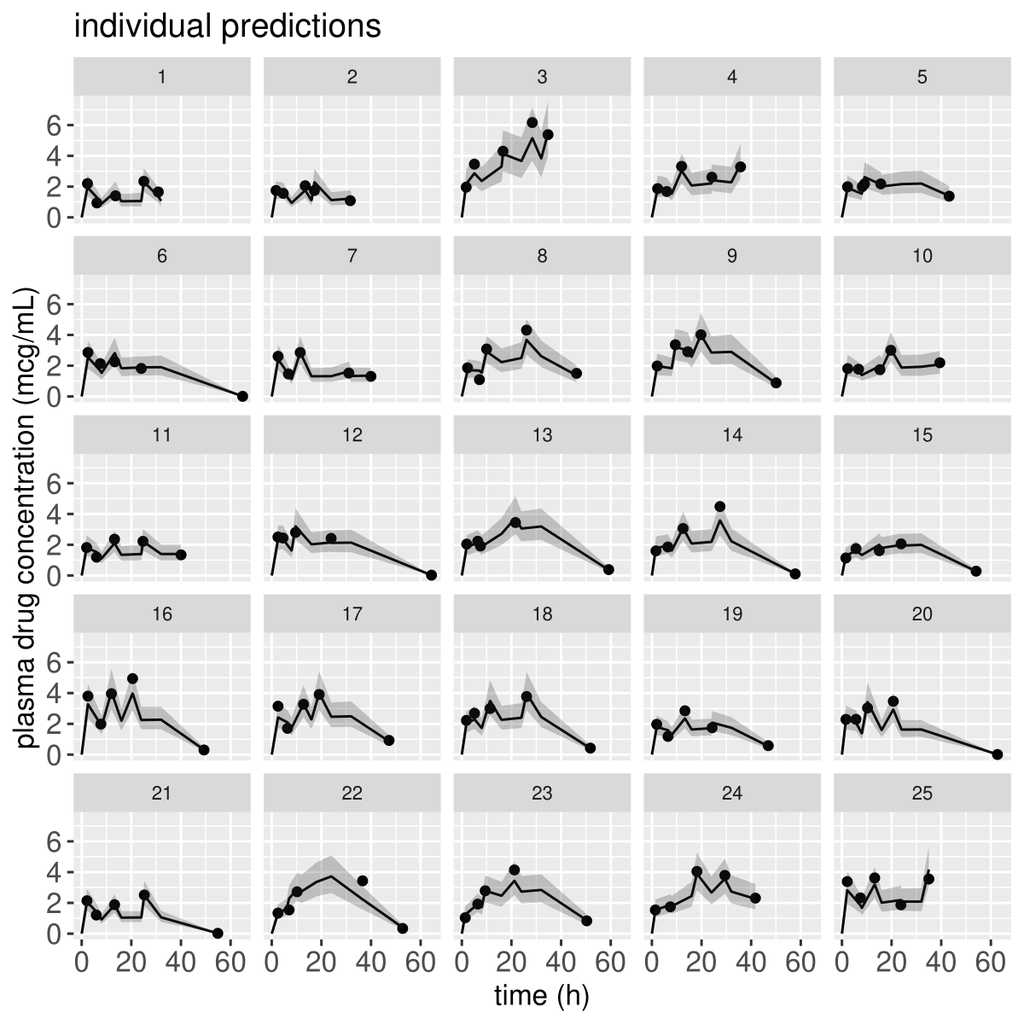

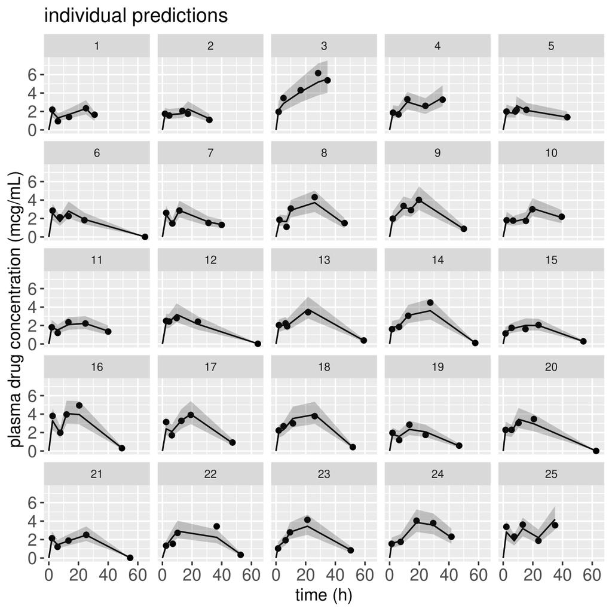

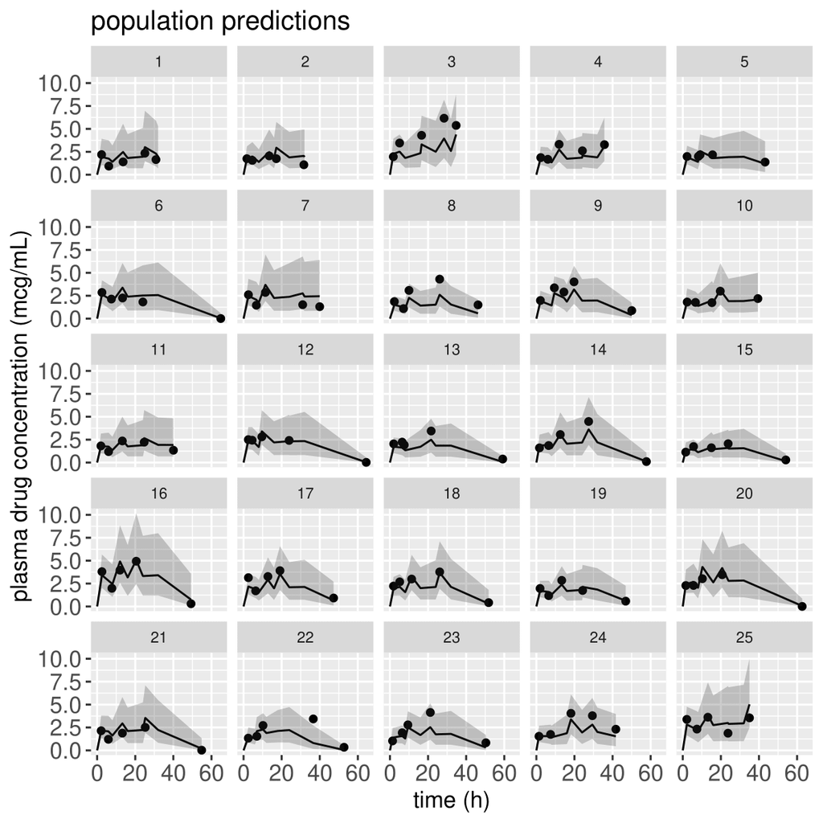

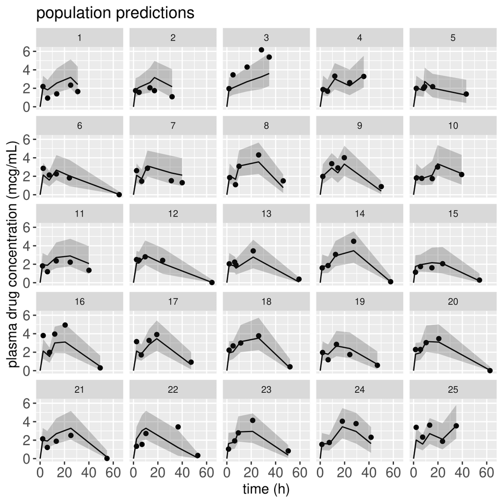

### neutropenia example

|  | mean | se_mean | sd | X2.5. | X25. | X50. | X75. | X97.5. | n_eff | Rhat | valid | Q5 | Q50 | Q95 | MCSE_Q2.5 | MCSE_Q25 | MCSE_Q50 | MCSE_Q75 | MCSE_Q97.5 | MCSE_SD | Bulk_ESS | Tail_ESS |
| --- | --- | --- | --- | --- | --- | --- | --- | --- | --- | --- | --- | --- | --- | --- | --- | --- | --- | --- | --- | --- | --- | --- |
| lp__ | 144.29802 | 0.09880 | 2.55040 | 138.42839 | 142.75042 | 144.64751 | 146.20168 | 148.19430 | 648 | 1.00740 | 1 | 139.46241 | 144.64751 | 147.81303 | 0.20439 | 0.13097 | 0.09702 | 0.06479 | 0.05295 | 0.06994 | 667 | 1123 |
| CL | 10.02442 | 0.00440 | 0.17941 | 9.67646 | 9.90765 | 10.02026 | 10.14449 | 10.37087 | 1647 | 1.00094 | 1 | 9.73406 | 10.02026 | 10.31410 | 0.01323 | 0.00480 | 0.00592 | 0.00643 | 0.01523 | 0.00313 | 1687 | 1252 |
| Q | 15.21073 | 0.04962 | 1.53096 | 12.41381 | 14.08091 | 15.13033 | 16.26955 | 18.21399 | 934 | 1.00065 | 1 | 12.82273 | 15.13033 | 17.76610 | 0.13436 | 0.04819 | 0.05706 | 0.06792 | 0.17153 | 0.03509 | 959 | 1190 |
| V1 | 35.98325 | 0.14298 | 4.22896 | 26.99915 | 33.17950 | 36.10948 | 38.82470 | 43.65412 | 864 | 1.00251 | 1 | 28.58541 | 36.10948 | 42.51085 | 0.33346 | 0.18362 | 0.15563 | 0.15647 | 0.40362 | 0.10113 | 892 | 1002 |
| V2 | 106.89091 | 0.18112 | 7.27937 | 93.91071 | 102.03767 | 106.52369 | 111.46249 | 121.79001 | 1577 | 1.00219 | 1 | 95.58826 | 106.52369 | 119.29980 | 0.31754 | 0.20861 | 0.22063 | 0.29064 | 0.60822 | 0.12983 | 1681 | 1580 |
| ka | 2.12299 | 0.01115 | 0.32733 | 1.49320 | 1.90255 | 2.11639 | 2.33941 | 2.78967 | 848 | 1.00206 | 1 | 1.58755 | 2.11639 | 2.66334 | 0.01898 | 0.01135 | 0.01290 | 0.01137 | 0.03656 | 0.00795 | 867 | 987 |
| sigma | 0.11177 | 0.00026 | 0.01160 | 0.09158 | 0.10364 | 0.11079 | 0.11863 | 0.13821 | 1955 | 1.00202 | 1 | 0.09426 | 0.11079 | 0.13313 | 0.00051 | 0.00032 | 0.00039 | 0.00042 | 0.00133 | 0.00019 | 2033 | 1175 |
| alpha | 0.00227 | 0.00002 | 0.00061 | 0.00117 | 0.00185 | 0.00224 | 0.00266 | 0.00351 | 823 | 1.00213 | 1 | 0.00133 | 0.00224 | 0.00332 | 0.00004 | 0.00002 | 0.00002 | 0.00003 | 0.00007 | 0.00002 | 853 | 968 |
| mtt | 127.20425 | 0.18671 | 5.82024 | 115.20940 | 123.48883 | 127.33372 | 130.84870 | 139.09999 | 952 | 1.00415 | 1 | 117.59352 | 127.33372 | 136.59679 | 0.57053 | 0.29519 | 0.20513 | 0.24668 | 0.25729 | 0.13206 | 986 | 934 |
| circ0 | 4.78723 | 0.00432 | 0.15282 | 4.50351 | 4.68445 | 4.78082 | 4.88382 | 5.10969 | 1236 | 1.00202 | 1 | 4.54369 | 4.78082 | 5.05734 | 0.00936 | 0.00460 | 0.00472 | 0.00474 | 0.01371 | 0.00306 | 1255 | 1230 |
| gamma | 0.18759 | 0.00067 | 0.02036 | 0.14939 | 0.17411 | 0.18619 | 0.20082 | 0.22850 | 916 | 1.00495 | 1 | 0.15551 | 0.18619 | 0.22224 | 0.00174 | 0.00092 | 0.00074 | 0.00098 | 0.00175 | 0.00047 | 916 | 1258 |
| sigmaNeut | 0.08345 | 0.00035 | 0.01337 | 0.06222 | 0.07420 | 0.08208 | 0.09076 | 0.11479 | 1425 | 1.00288 | 1 | 0.06481 | 0.08208 | 0.10757 | 0.00048 | 0.00030 | 0.00033 | 0.00051 | 0.00173 | 0.00026 | 1615 | 1071 |

|  | mean | se_mean | sd | X2.5. | X25. | X50. | X75. | X97.5. | n_eff | Rhat | valid | Q5 | Q50 | Q95 | MCSE_Q2.5 | MCSE_Q25 | MCSE_Q50 | MCSE_Q75 | MCSE_Q97.5 | MCSE_SD | Bulk_ESS | Tail_ESS |
| --- | --- | --- | --- | --- | --- | --- | --- | --- | --- | --- | --- | --- | --- | --- | --- | --- | --- | --- | --- | --- | --- | --- |
| CL | 10.01785 | 0.00498 | 0.17111 | 9.67613 | 9.90614 | 10.02215 | 10.13402 | 10.33158 | 1174 | 0.99883 | 1 | 9.73021 | 10.02215 | 10.27703 | 0.02304 | 0.00923 | 0.00495 | 0.00660 | 0.02525 | 0.00353 | 1216 | 786 |
| Q | 15.46115 | 0.06280 | 1.58253 | 12.61821 | 14.35833 | 15.42750 | 16.50575 | 18.71709 | 620 | 1.00354 | 1 | 12.91578 | 15.42750 | 18.10592 | 0.06995 | 0.05720 | 0.07645 | 0.10145 | 0.17160 | 0.04458 | 638 | 767 |
| V1 | 34.89810 | 0.22315 | 4.73266 | 25.58776 | 31.80400 | 35.14855 | 37.95963 | 43.72121 | 446 | 1.01159 | 1 | 26.61998 | 35.14855 | 42.42157 | 0.44795 | 0.32840 | 0.24365 | 0.21385 | 0.28645 | 0.15789 | 451 | 249 |
| V2 | 106.92459 | 0.22232 | 7.20483 | 93.14088 | 102.21675 | 106.76800 | 111.75200 | 121.04273 | 1017 | 1.00182 | 1 | 95.72471 | 106.76800 | 119.24190 | 0.83515 | 0.30650 | 0.30500 | 0.29300 | 0.27700 | 0.15725 | 1039 | 728 |
| ka | 2.03854 | 0.01523 | 0.34700 | 1.40684 | 1.80448 | 2.04216 | 2.26595 | 2.74780 | 516 | 1.01160 | 1 | 1.47204 | 2.04216 | 2.60016 | 0.02734 | 0.02020 | 0.01478 | 0.01374 | 0.04158 | 0.01078 | 465 | 303 |
| sigma | 0.11182 | 0.00038 | 0.01205 | 0.09170 | 0.10334 | 0.11084 | 0.11879 | 0.13850 | 1002 | 0.99959 | 1 | 0.09428 | 0.11084 | 0.13218 | 0.00078 | 0.00054 | 0.00041 | 0.00054 | 0.00125 | 0.00027 | 1098 | 766 |
| alpha | 0.00028 | 0.00000 | 0.00002 | 0.00025 | 0.00027 | 0.00028 | 0.00029 | 0.00031 | 870 | 1.00506 | 1 | 0.00025 | 0.00028 | 0.00031 | 0.00000 | 0.00000 | 0.00000 | 0.00000 | 0.00000 | 0.00000 | 883 | 970 |
| mtt | 119.15494 | 0.23305 | 5.93504 | 107.48910 | 115.15300 | 119.02500 | 123.07350 | 131.19002 | 634 | 1.00734 | 1 | 109.89320 | 119.02500 | 129.10955 | 1.23900 | 0.36050 | 0.23250 | 0.24450 | 0.43950 | 0.16487 | 654 | 816 |
| circ0 | 4.74647 | 0.00595 | 0.15203 | 4.45550 | 4.65409 | 4.73887 | 4.84470 | 5.04735 | 643 | 1.00606 | 1 | 4.49928 | 4.73887 | 5.00007 | 0.01526 | 0.00667 | 0.00523 | 0.00855 | 0.00957 | 0.00421 | 655 | 561 |
| gamma | 0.18297 | 0.00084 | 0.02018 | 0.14663 | 0.16934 | 0.18161 | 0.19567 | 0.22436 | 571 | 1.00846 | 1 | 0.15161 | 0.18161 | 0.21603 | 0.00258 | 0.00088 | 0.00087 | 0.00085 | 0.00183 | 0.00060 | 588 | 609 |
| sigmaNeut | 0.08335 | 0.00039 | 0.01244 | 0.06294 | 0.07445 | 0.08236 | 0.09020 | 0.11155 | 1010 | 1.00269 | 1 | 0.06569 | 0.08236 | 0.10546 | 0.00091 | 0.00039 | 0.00048 | 0.00053 | 0.00227 | 0.00028 | 1083 | 937 |

The prediction of CObs (top) and NeutObs (bottom) from non-Torsten neutropenia (left) and Torsten neutropenia (right). CObs and NeutObs are the same for the two models.

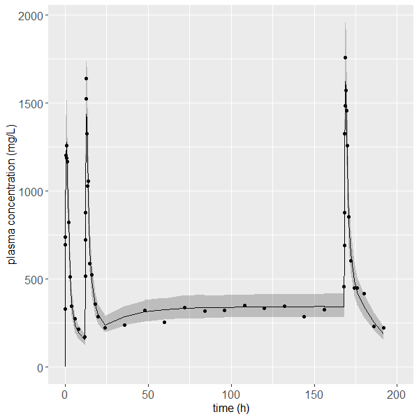

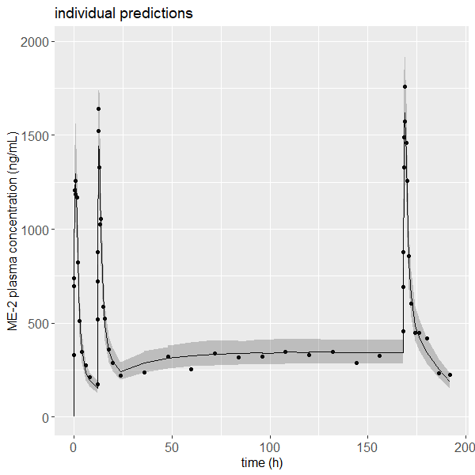

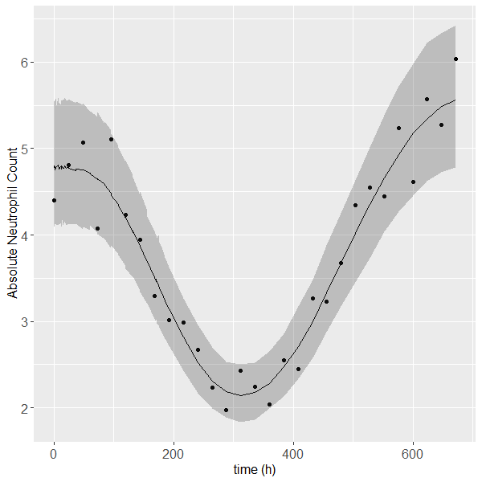

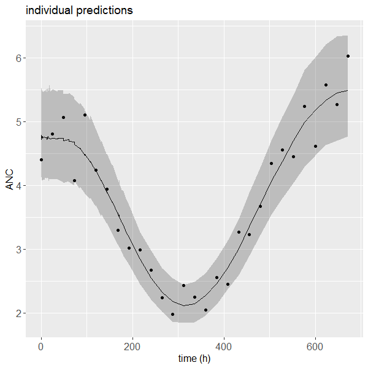